## Reading: CheatSheet - Creating Database Objects and Querying Data from R

Command

Syntax

Description

Example

sqlQuery()

`sqlQuery(conn, _QUERY_, errors=FALSE)`

`sqlQuery` function submits an SQL query that is passed as the second parameter to an ODBC database connection, and retrieve the results.  
conn - connection  
_QUERY_ - The query you want to execute on the database  
errors - logical: if true halt and display error, else return -1.

**Code**  
`sqlQuery(conn, "SELECT COUNT(B_ID) FROM BOARD;")`  
**Output**

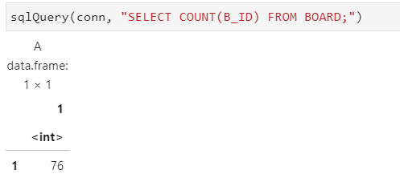

sqlTables()

`sqlTables(conn, schema = schemaname)`

`sqlTables` function list the table-like objects accessible from an ODBC connection.

**Code**  
`sqlTables(conn)`  
**Output**

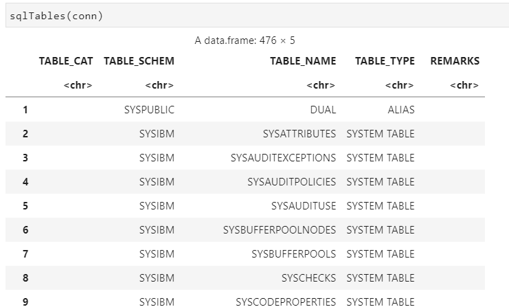

sqlTypeInfo()

**Code**  
`sqlTypeInfo(conn)`

`sqlTypeInfo` function request information about column types in an ODBC database.

**Code**  
`sqlTypeInfo(conn)`  
**Output**

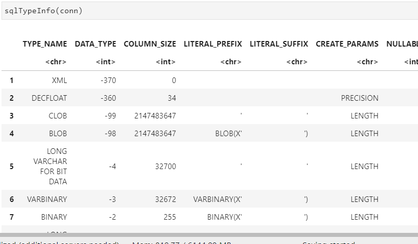

odbcGetInfo()

**Code**  
`odbcGetInfo(conn)`

`odbcGetInfo` function requests information on an ODBC connection.

**Code**  
`odbcGetInfo(conn)`  
**Output**

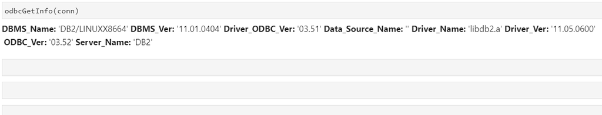

nrow

`nrow(x)`

`nrow` returns the number of rows present in x.

**Code**

```
ma <- matrix(1:12, 3, 4)
nrow(ma)
```

**Output**

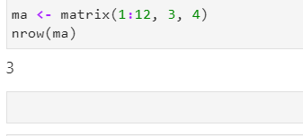

ncol

`ncol(x)`

`ncol` returns the number of columns present in x.

**Code**

```
ma <- matrix(1:12, 3, 4)
ncol(ma)
```

**Output**

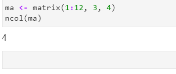

paste

`paste(..., sep = " ", collapse = NULL)`

`paste` concatenates vectors after converting to them character.

**Code**

```
secquery <- paste("select s.enrollment as ENROLLMENT
from school s, board b
where b.b_name = 'Toronto DSB' and b.b_id=s.b_id
and s.level = 'Secondary'
order by enrollment desc")
```

**Output**

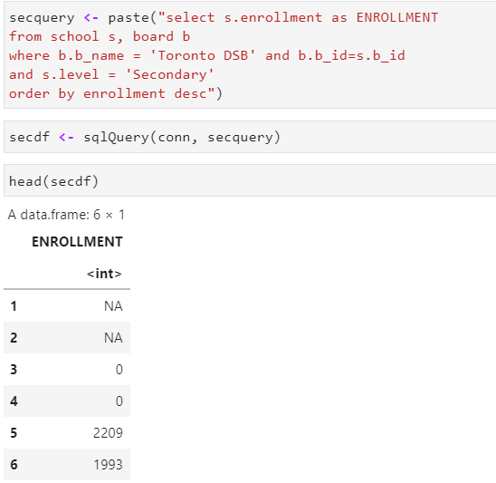

cat

`cat(...,file = “”, sep = ” “, fill = FALSE, labels = NULL, append = FALSE)`

`cat` Returns the concatenated objects passed as parameters

**Code**  
`cat('one',2,'three',4,'five') #one 2 three 4 five`  
**Output**

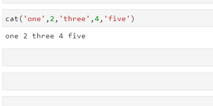

odbcGetErrMsg()

`odbcGetErrMsg(conn)`

`odbcGetErrMsg` returns a (possibly zero-length) character vector of pending messages.

iconv()

`iconv(x, from = "", to = "", sub = NA, mark = TRUE, toRaw = FALSE)`

`iconv` uses system facilities to convert a character vector between encodings: the ‘i’ stands for internationalization.

**Code**

```
x <- "fa\xE7ile"
iconv(x, "latin1", "ASCII", "?")
```

**Output**

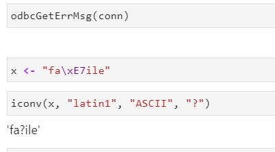

sqlSave()

`sqlSave(conn, dat, tablename = NULL, append = FALSE,rownames = TRUE, colnames= FALSE, verbose = FALSE,safer = TRUE, addPK = FALSE, typeInfo, varTypes,fast = TRUE, test = FALSE, nastring = NULL)`

`sqlSave` writes or updates a table in an ODBC database.

**Code**  
`sqlSave(conn, boarddf, "BOARD", append=TRUE, fast=FALSE, rownames=FALSE, colnames=FALSE, verbose=FALSE)`  
**Output**

[figure not shown]

sqlFetch()

`sqlFetch(conn, sqtable, ..., colnames = FALSE, rownames = TRUE)`

`sqlFetch` Reads some or all of a table from an ODBC database into a dataframe.

**Code**  
`sqlFetch(conn, "BOARD")`  
**Output**

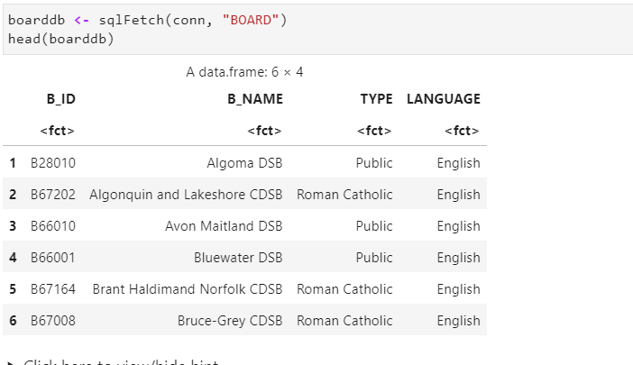

qplot()

`qplot(x,y,...,data,facets = NULL,margins = FALSE,geom = "auto", xlim = c(NA, NA),ylim = c(NA, NA),log = "",main = NULL,xlab = NULL,ylab = NULL,asp = NA, stat = NULL, position = NULL)`

`qplot()` is a shortcut designed to be familiar if you're used to base plot(). It's a convenient wrapper for creating a number of different types of plots using a consistent calling scheme.

**Code**  
`qplot(ENROLLMENT, data=eledf, geom="density", main="TDSB School Size - Elementary")`  
**Output**

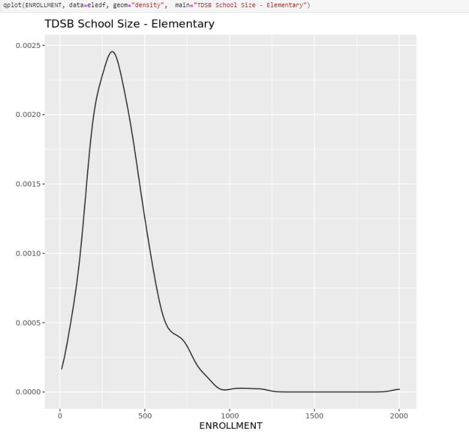